# StatTeam6_final

Stuart Gavidia, Joana Hadzhilazova, Eric Aguirre, & Lisa Ha

12/7/2021

Part I - Lisa

# Exploratory Data Analysis

We begin our study of the `project_data` data with some exploratory data analysis. This particular data set has 8840 rows and 8 columns. The variables are `country`, `continent`, `year`, `life_exp`, `population`, `num_phones`, `net_users` and `non_net_users`. The first few are fairly self-explanatory as to what they represent. For the others, `life_exp` is the life expectancy of someone born in that country during that specific year, and `population` is the population of the country in the given year.

For This presentation, we will be focusing on the relationship between life expectancy and the number of internet users in a given country. First, let’s examine net_users by continent:

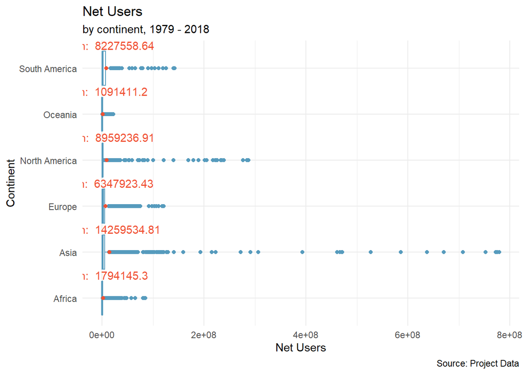

Let’s remove some of the outliers to make this a bit easier to read:

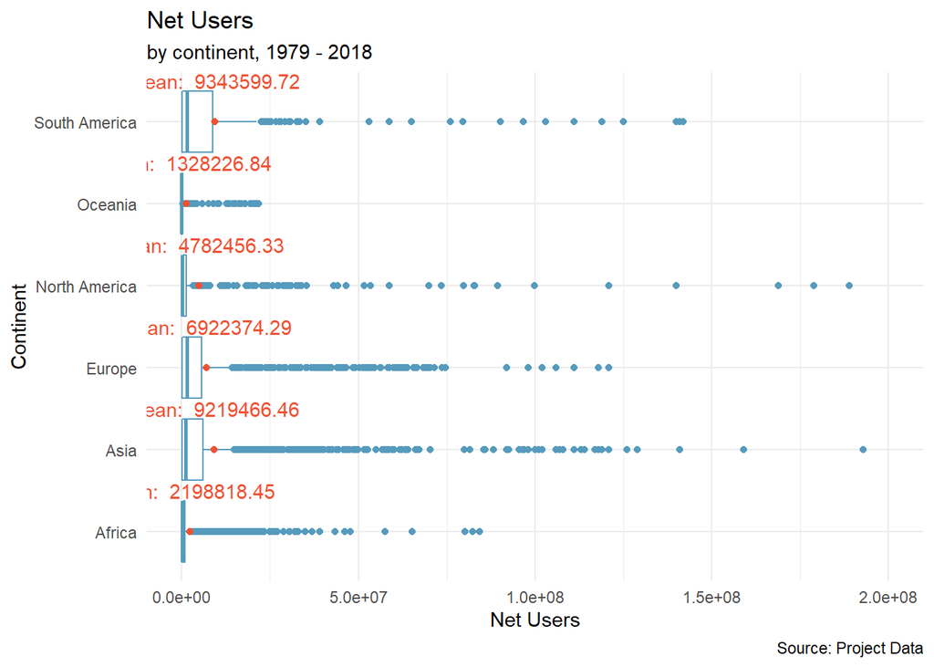

It’s quite clear even after removing a good number of the outlying data, that there are many extreme values across all continents, and most of the data lie on the lower side of the spectrum.

Now, let’s take a look at life_exp:

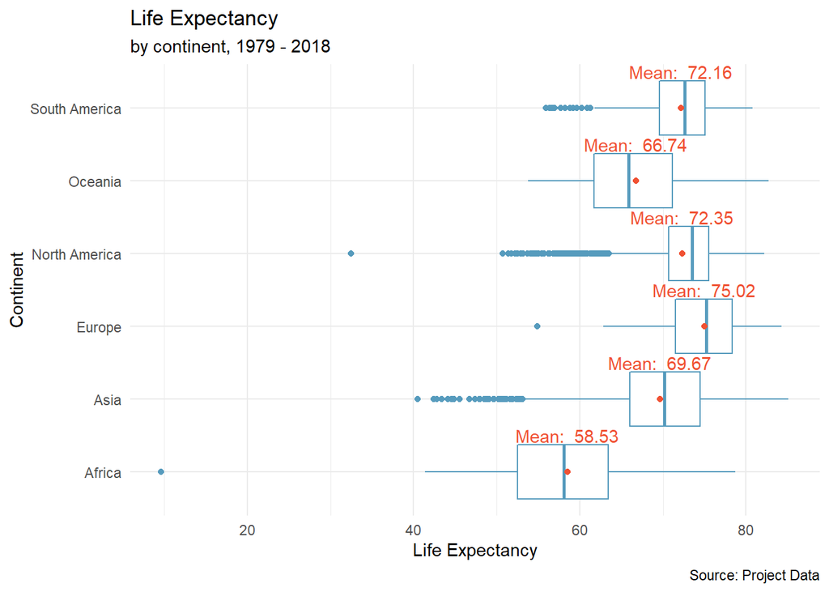

Overall there is a lot less variation compared to the data for net_users. Most continents have a mean life expectancy hovering around the high 60s/low 70s, apart from africa with a mean of about 58.

Part II -Eric

# Data Visualization

Now, let’s go through a few plots to provide some context.

### A Scatterplot of net_users v year

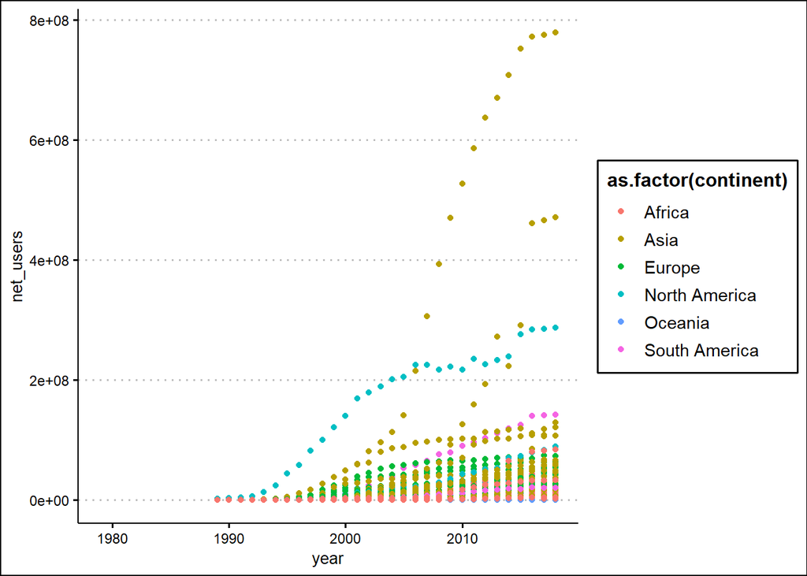

The scatter plot shows the sharpest increase of internet users in Asia, starting around 2005. There is also a dramatic increase in North America, which started much earlier, around 1995. Other continents, however, only showed a steady increase of users beginning in the late 90s.

### Extra Scatterplot life_exp v year

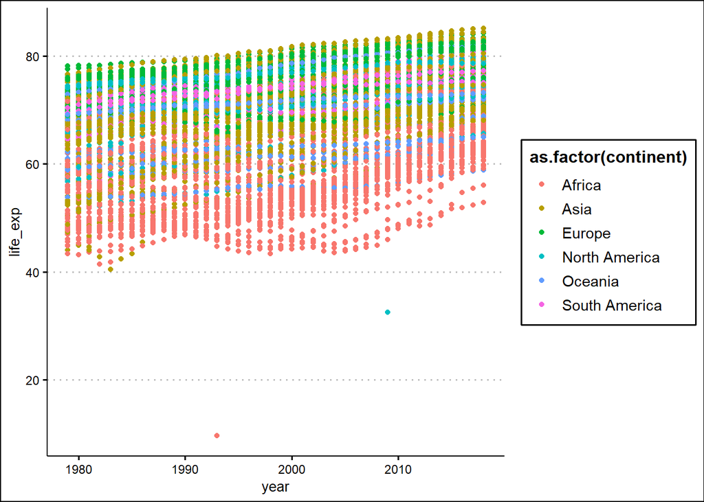

This plot shows a very steady increase in life expectancy across all continents between 1979 and 2018. From the distribution you can tell that Africa has almost exclusively the lowest life expectancy, while the other continents tend to vary a bit more.

### Life Expectancy v net users

Now, let’s combine the two graphs, again coloring by continent:

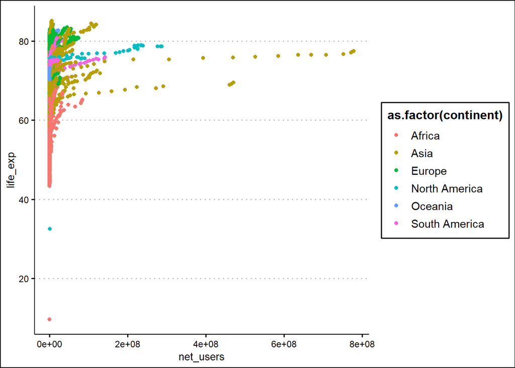

While most of the data are consolidated to the extreme left of the scale, some correlation can be seen, especially in North America and Asia.

### Separated by continent

Let’s look at this data again, separated by continent.

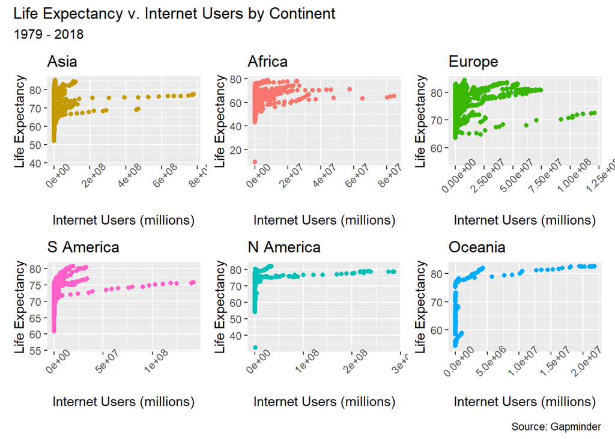

The distinction by continent helps us more clearly see the correlation of the two variables, despite data consolidation on the left.

Part III - Joana

# Linear Modeling

## The focus here will be comparing Life Expectancy and Net Users Globally and the relationship between these two variables will be analyzed using a scatterplot.

### Plot regression model

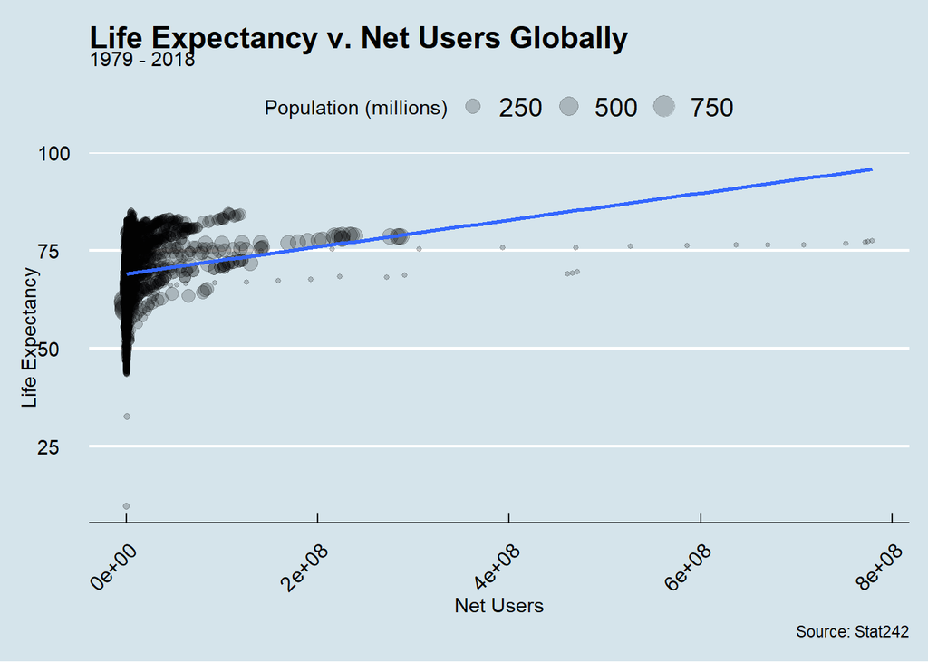

```
## # A tibble: 6 x 2
##   continent       cor
##   <chr>         <dbl>
## 1 Africa           NA
## 2 Asia             NA
## 3 Europe           NA
## 4 North America    NA
## 5 Oceania          NA
## 6 South America    NA
```

The time frame throughout which our data was recorded is the span of years from 1979 to 2018 as seen in the facet wrap graph below.

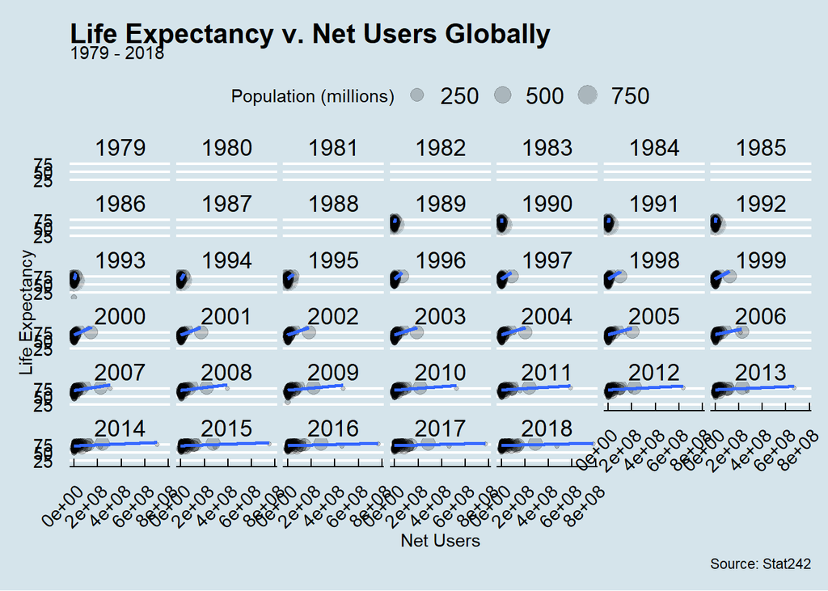

Zooming in on the facet wrap graph we can see that the three-dot-cluster that make up the outlier, appear in the years 2016-2018. Furthermore, the size of the dot under these three years corresponds to a small population according to the key at the top of the graph. Looking at the number of net user associated with the outlier is approximately 4.5 x 108.

Knowing this information, we can find which country in the project_data table contains these parameters and can identify which country is the outlier.

We conclude that the outlier is India. It is tabulated under in the year 2018, is part of the continent Asia, and contains 4.71 x 108 net users. This confirms the descriptions we observed earlier from the facet wrap graph.

We can now write code to exclude India from the dataset and recalculate the correlation of Asia.

```
## # A tibble: 1 x 1
##     cor
##   <dbl>
## 1 0.152
```

Finally, recreating the scatterplot of our data with the new correlation lacking India, we see that the points are more closely clustered around the regression line and the outlier dot(s) are missing. The confirmation that there is a relationship between Life Expectancy and Net Users Globally stands.

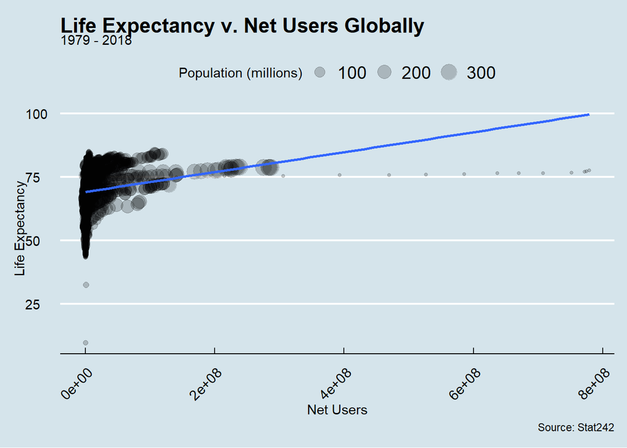

Part IV - Stuart

## Test: is this significantly lower from the average?

```
## (Intercept)
##    0.245743
```

Our p-value is greater than 0.05, we fail to reject the null hypothesis. Therefore we conclude, a South American country in the year 6000 will not have an unusually low life expectancy.

## Proportion net users of a country with rest of world

```
## [1] 0.4717434
```